# Examples of non-regular sampling distributions

Marshall B.

Wednesday, April 16, 2014

Before we explore areas where inference fails for measures of risk prediction, it is helpful to look at examples where the sampling distribution is non-regular. This document highlights some of these examples.

Note that different measures have different ‘problem areas.’ For example, $HR_D(r_H)$ will fail when $P(Risk(X_D) = r_H) \neq 0$. Below we step through each measure and find an example where the sampling distribtion is non-regular. However, the simulation model for all examples is:

$\begin{aligned} Pr(D = 1) & = \rho\\ Y_\bar D & \sim N( \tilde 0 , \Sigma) \\ Y_D & \sim N( \tilde \mu , \Sigma) \end{aligned}$ which induces a linear logistic model

$Pr(D = 1 | Y) = expit(logit(\rho) + (1/2)((x - \mu)' \Sigma^{-1} (x-\mu) - x' \Sigma^{-1} x))$

## Evaluate a single risk Model

For the examples here

- $\rho = 0.1$,
- $Y$ is 3 dimensional with $\mu_i = .2$ for each marker,
- all pairwise correlations equal to $0.1$ and marginal $\sigma_i = 1$.

Sampling distributions for estimates based on fitted risks using logistic regression were obtained from 5,000 simulations for each $rh$. The sample size was set at $n = 250$.

### Measures that depend on $r_H$

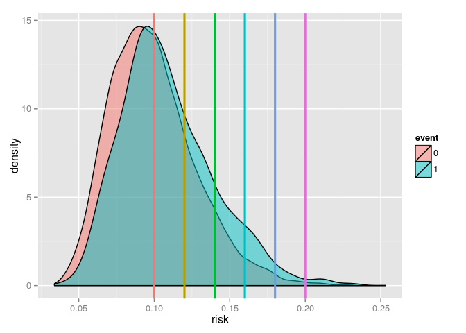

Figure 1: plot of the distribution of risk given event status. Risk thresholds *rh* shown as vertical lines.

#### 1.$HR_D(r_H) = P(risk(X) > r_H | D = 1)$

**Hypothesis:** Problems will arise when $P(Risk(X_D) = r_H) \neq 0$, which happens when $rh$ is near $0.1$. This should be less of a problem when $rh$ is large.

**Observation:** Sampling distributions for conditional measure estimates are shown below. The true values for each corresponding $rh$ are indicated by vertical lines. We see that the sampling distributions are highly non-normal for high risk thresholds, which is most likely due to the fact that $HR_D (r_H)$ gets smaller as $rh$ gets larger. This plot seems to contradict our hypothesis. Also note the systematic positive bias in the estimates, which may be due to overfitting.

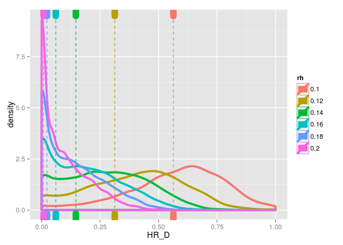

Figure 2: plot of sampling distribution of HR_D(rh) for different values of rh. calculated using 5000 simulations. true values shown by the vertical lines.

#### 2. $HR_{\bar D}(r_H) = P(risk(X) > r_H | D = 0)$

**Hypothesis:** Problems will arise when $P(Risk(X_D) = r_H) \neq 0$, which happens when $rh$ is near $0.1$. This should be less of a problem when $rh$ is large.

**Observation:** We see that the sampling distributions are highly non-normal for high risk thresholds, which is most likely due to the fact that $HR_\bar D (r_H)$ gets smaller as $rh$ gets larger. This plot also seems to contradict our hypothesis. In this case there is slight systematic negative bias (overoptimism) in the estimates, but not as drastic as for $HR_D$.

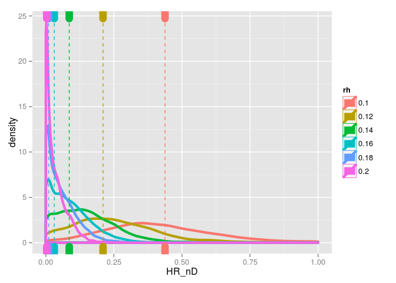

Figure 3: plot of sampling distribution of HR_Dbar(rh) for different values of rh. calculated using 5000 simulations. true values shown by the vertical lines.

#### 3. $NB(r_H) = \rho HR_D(r_H) - (1-\rho)\frac{r_h}{(1-r_H)}HR_{\bar D}(r_H)$

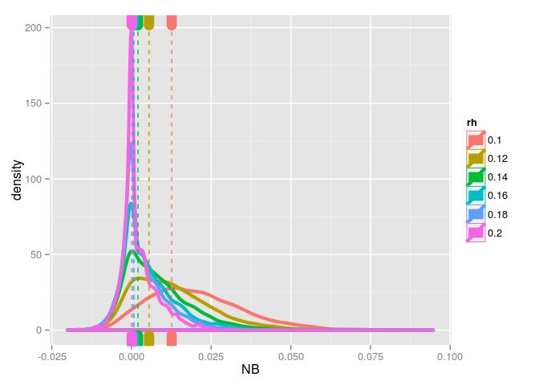

Figure 4: plot of sampling distribution of NB(rh) for different values of rh. true values shown by the vertical lines.

#### 4. $sNB(r_H) = HR_D(r_H) - \frac{(1-\rho)}{\rho} \frac{r_h}{(1-r_H)}HR_{\bar D}(r_H)$

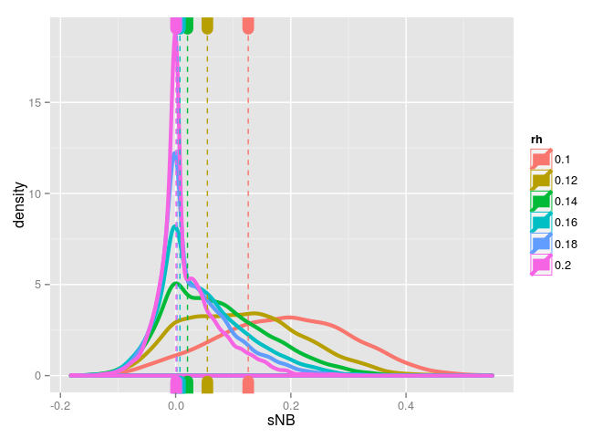

Figure 5: plot of sampling distribution of sNB(rh) for different values of rh. true values shown by the vertical lines.

### Measures that are independ of $r_H$

Here I include sampling distributions for measures based on fitted risk (conditional estimates) and for measures estimating using risks determined by the true model.

#### 5. $AUC = Pr(risk(X_i ) \geq risk(X_j ) | D_i = 1, D_j = 0 )$

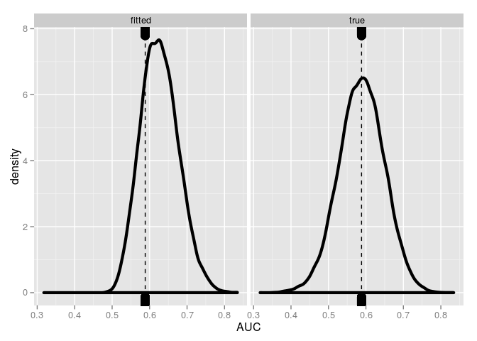

#### 6. $MRD = E( risk(X) | D = 1) - E( risk(X) | D =0)$

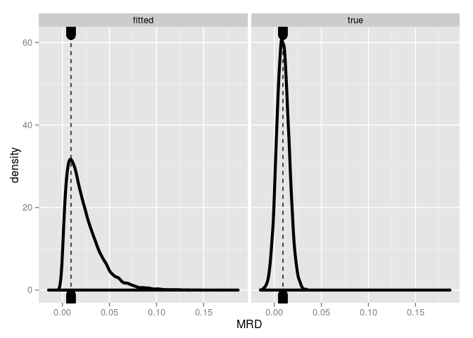

#### 7. $AARD = Pr(risk(X) > \rho | D = 1) - Pr(risk(X) > \rho | D = 0)$

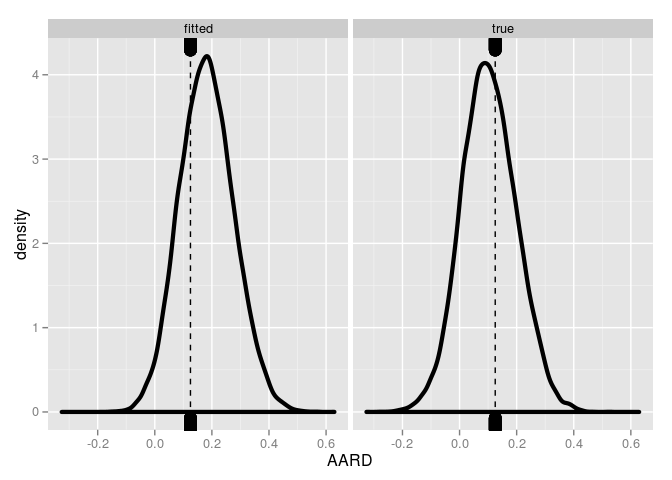